# Network Analytics in R: Chapter 3

### Random Graphs for Context

Numbers above don’t have much meaning without context. In order to provide some context, **random graphs** are generated by algorithm to match characteristics of a given graph. The stats for the random graphs can be used to compare against particular graph.

Generate single random graph

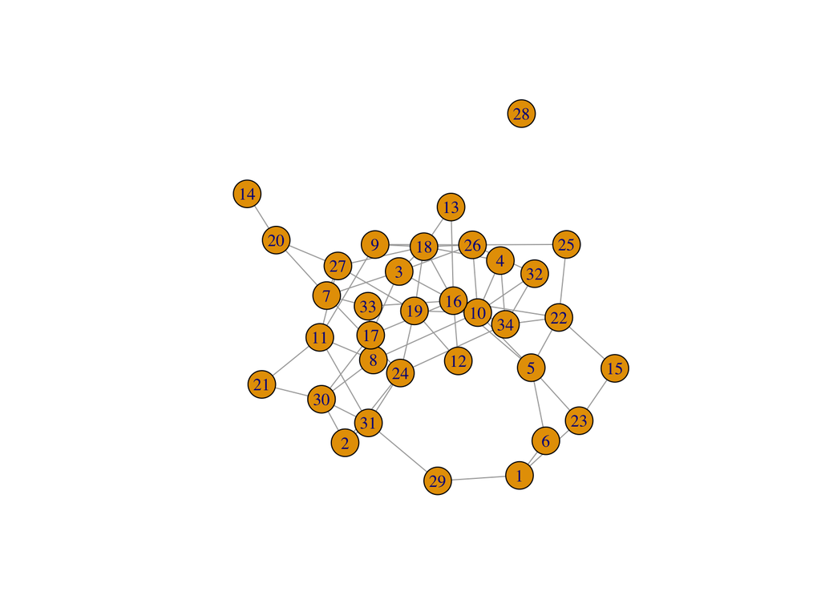

```r
g.random <- erdos.renyi.game(n=gorder(g), p.or.m = gden, type='gnp')

plot(g.random)
```

```r
edge_density(g.random)
```

```
## [1] 0.1158645
```

```r
mean_distance(g.random, directed = FALSE)
```

```
## [1] 2.679924
```

Generate multiple random graphs for comparison

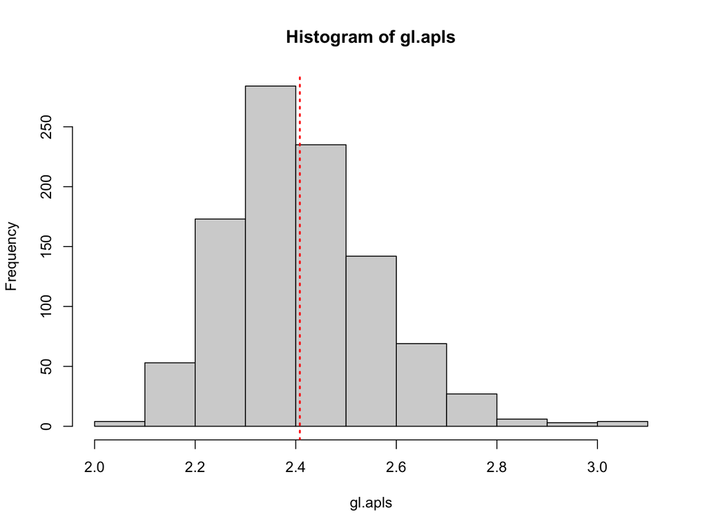

```r
## generate 1000 graphs
gnum <- 1000
gl <- vector('list',gnum)

for(i in 1:gnum){
  gl[[i]] <- erdos.renyi.game(n=gorder(g),
                              p.or.m=gden,
                              type='gnp')
}

gl.apls <- unlist(lapply(gl, mean_distance, directed=FALSE))

hist(gl.apls)
abline(v=gad, col='red', lty=3, lwd=2)
```

```r
## calc % of time avg distance from random generated ## graphs is lower than original graph

mean(gl.apls < gad)
```

```
## [1] 0.528
```

### Network Substructures

Methods for describing network sub-structure.

#### Triangles and transivity

How many closed triangles, as proportion of all possible triangles within graph?

#### Cliques

- Every vertex connected to every other vertex
- Rare situation
- More common some vertices connected together within larger network (for these, all triangles are closed)

```r
## TRANSITIVITY
## all triangles in network
matrix(triangles(g), nrow=3)
```

```
##      [,1] [,2] [,3] [,4] [,5] [,6] [,7] [,8] [,9] [,10] [,11] [,12] [,13] [,14]
## [1,]   34   34   34   34   34   34   34   34   34    34    34    34    34    34
## [2,]    8   17   17   23   25   26   26   26   26    26    26    26    26    26
## [3,]   24   21   23   20   22    8   11   12   13    15    16    17    23    24
##      [,15] [,16] [,17] [,18] [,19] [,20] [,21] [,22] [,23] [,24] [,25] [,26]
## [1,]    34     1     1     1     1     1     1     1     1     1     1     1
## [2,]    26     2     2     2     2     2     2     3     3     3     3     3
## [3,]    25    32    31     4    10    14    27    27     2     4     8    10
##      [,27] [,28] [,29] [,30] [,31] [,32] [,33] [,34] [,35] [,36] [,37] [,38]
## [1,]     1     1     1     1     1     1     1    26    26    26     3     3
## [2,]     4     4     4     5     6     6     7     3     8    17     2     2
## [3,]    30    27    10    28     7    28     5     8    24    23     4    10
##      [,39] [,40] [,41] [,42] [,43] [,44] [,45]
## [1,]     3     3     3     2     2    25     6
## [2,]     2     4     4     4     4    18     7
## [3,]    27    27    10    27    10    19    33
```

```r
## count of triangles with 'Actor 3' in vertex
count_triangles(g, vids='Actor 3')
```

```
## [1] 11
```

```r
## global transitivity
g.tr <- transitivity(g)
g.tr
```

```
## [1] 0.2556818
```

```r
# local transitivity for 'Actor 3'
transitivity(g, vids='Actor 3', type='local')
```

```
## [1] 0.2444444
```

Back to randomizations to analyze transivity:

- is transitivity for our network higher/lower than what we would expect by chance for networks with similar size and density?

```r
## transitivity comparisons via randomization
gl.tr <- lapply(gl, transitivity)
gl.trs <- unlist(gl.tr)
summary(gl.trs)
```

```
##    Min. 1st Qu.  Median    Mean 3rd Qu.    Max.
## 0.02542 0.11389 0.13636 0.13672 0.16002 0.23438
```

```r
mean(gl.trs > gl.tr)
```

```
## [1] 0
```

```r
## CLIQUES
largest_cliques(g)
```

```
## [[1]]
## + 5/34 vertices, named, from 1f8783d:
## [1] Actor 8 Mr Hi   Actor 2 Actor 3 Actor 4
##
## [[2]]
## + 5/34 vertices, named, from 1f8783d:
## [1] Actor 4  Mr Hi    Actor 2  Actor 3  Actor 14
```

```r
## identify maximal cliques
clq <- max_cliques(g)
## calc size of max clique
table(unlist(lapply(clq, length)))
```

```
##
##  2  3  4  5
## 11 21  2  2
```

#### Visualize largest cliques

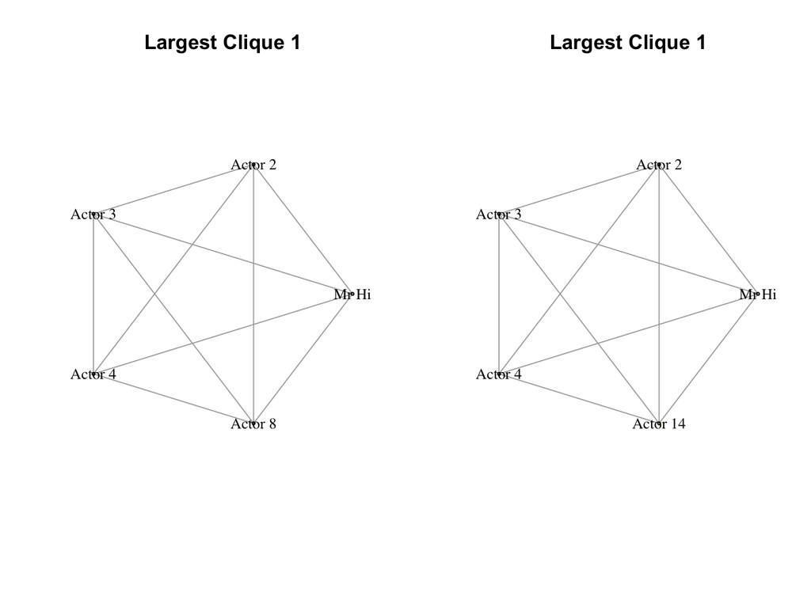

```r
lc <- largest_cliques(g)
gs1 <- as.undirected(subgraph(g, lc[[1]]))
gs2 <- as.undirected(subgraph(g, lc[[2]]))
## show plots side by side
par(mfrow=c(1,2))

plot(gs1,
     vertex.label.color='black',
     vertex.label.cex=0.9,
     vertex.size=0,
     main='Largest Clique 1',
     layout=layout.circle(gs1))

plot(gs2,
     vertex.label.color='black',
     vertex.label.cex=0.9,
     vertex.size=0,
     main='Largest Clique 1',
     layout=layout.circle(gs1))
```